# HCC pilot — random-effect vs interaction tissue formula

V1_nk liver baseline sanity check on 4 TIMES biomarkers

Author

Affiliation

Chen Zhan

SAiGENCI, The University of Adelaide

Published

15 Jul 2026

Abstract

# Motivation

The TIMES HCC case study uses a **comprehensive healthy liver NK baseline** from the posteriorHCA `V1_nk` atlas. Each gene is modelled as a zero-inflated negative binomial regression on pseudobulk counts with rich covariate structure. In production, **tissue-specific deviations** enter as random effects:

$$\texttt{(1 + age\_decade * sex + ethnicity\_groups | tissue\_groups)}$$

This partial pooling is attractive when many tissues contribute information, but **liver contributes only 71 of 3,226 NK pseudobulk samples** (2.2%), while blood contributes 74%. A concern for the HCC application is that liver tissue effects — and liver-specific age/sex/ethnicity slopes — may be **shrunk toward the blood-dominated population mean**, appearing as if liver biology is embedded in the global fixed effect rather than estimated independently.

An alternative is to replace the random-slopes tissue term with **fixed interactions**:

$$\texttt{age\_decade:tissue\_groups + sex:tissue\_groups + ...}$$

This removes hierarchical shrinkage: liver coefficients are estimated only from liver rows. The trade-off is a much larger parameter space and potential instability when liver sample size is modest.

## The shape (dispersion) formula, revisited

Both families share the same negative-binomial **shape** (dispersion) sub-model. In the previous pilot the shape formula carried **tissue- and ethnicity-specific terms**, so the liver dispersion was estimated largely from the 71 liver rows. We hypothesise that **this shape structure — not the mean formula — is what inflates the posterior SD of the liver baseline**: a poorly identified per-tissue dispersion widens the joint posterior, including the mean linear predictor `log(μ)` we read off as the baseline.

This revision therefore **simplifies the shape formula** so dispersion borrows power across all tissues instead of being anchored to small per-tissue samples:

- **Interaction shape** → `shape ~ 1 + disease_groups_altered + assay_groups_altered`
- **Random-effect shape** → `shape ~ 1 + disease_groups_altered + assay_groups_altered + (1 | tissue_groups)`

To attribute any SD change to the shape formula rather than the mean formula, we refit each family under **both** the revised *simple* shape and the previous *rich* shape while holding the counts formula fixed.

This report is a **pilot on four TIMES biomarkers** present in the `V1_nk` store. It compares **both families** (random-effect and interaction) x **both shape variants** (simple and rich). The fits are **precomputed once** by `R/HCC_re_vs_interaction_pilot.R` (run on a compute node with `cores = 32`; the random-slopes RE fit is too heavy for the login node) and cached as `fit_<family>[_rich]_<GENE>.rds` under `params$out_dir`. The training data and the rich-shape RE reference are read from the production targets store. **Rendering only reads the cached artefacts — it never fits models.**

# Formulas compared

Each family keeps its own **counts (mean) formula** and is fit under two **shape (dispersion) formulas**: the revised *simple* shape and the previous *rich* shape. The counts formula is identical across the two shape variants, so any difference in the baseline is attributable to the shape sub-model alone.

```r
source(file.path(params$case_dir, "R", "re_vs_interaction_helpers.R"))
specs <- formula_specs()

knitr::kable(data.frame(
  family = c("random-effect", "random-effect", "random-effect",
             "interaction", "interaction", "interaction"),
  component = c("counts", "shape (rich, reference)", "shape (simple, revised)",
                "counts", "shape (rich, reference)", "shape (simple, revised)"),
  formula = c(specs$re$counts, specs$re$shape_rich, specs$re$shape_simple,
              specs$interaction$counts, specs$interaction$shape_rich, specs$interaction$shape_simple)
))
```

| family | component | formula |
| --- | --- | --- |
| random-effect | counts | counts ~ 1 + offset(offset) + age_decade * sex + disease_groups_altered + ethnicity_groups + assay_groups_altered + (1 \| dataset_id_altered) + (1 + age_decade * sex + ethnicity_groups \| tissue_group… |
| random-effect | shape (rich, reference) | shape ~ 1 + disease_groups_altered + assay_groups_altered + ethnicity_groups + (1 \| tissue_groups) |
| random-effect | shape (simple, revised) | shape ~ 1 + disease_groups_altered + assay_groups_altered + (1 \| tissue_groups) |
| interaction | counts | counts ~ 1 + offset(offset) + disease_groups_altered + assay_groups_altered + (1 \| dataset_id_altered) + tissue_groups + age_decade:tissue_groups + sex:tissue_groups + age_decade:sex:tissue_groups + … |
| interaction | shape (rich, reference) | shape ~ 1 + disease_groups_altered + assay_groups_altered + ethnicity_groups + tissue_groups |
| interaction | shape (simple, revised) | shape ~ 1 + disease_groups_altered + assay_groups_altered |

The random-effect counts formula treats tissue deviations as random slopes; the interaction counts formula is their fixed-effect expansion inside `tissue_groups`. The **rich shape** carries `ethnicity_groups` (and a tissue term), while the **simple shape** drops those so dispersion pools across tissues.

# Library setup

```r
suppressPackageStartupMessages({
  library(tibble)
  library(tidyr)
  library(dplyr)
  library(readr)
  library(ggplot2)
  library(forcats)
  library(scales)
  library(glue)
})

theme_set(theme_minimal(base_size = 11))
dir.create(params$out_dir, recursive = TRUE, showWarnings = FALSE)
```

# Load precomputed baselines (fits are NOT run during rendering)

For each gene we fit four brms models — {random-effect, interaction} x {simple, rich shape} — with `cores = 32`. The random-slopes RE fit is **expensive and must run on a compute node, not the login node and not during rendering**. Fits are therefore **precomputed once** by `R/HCC_re_vs_interaction_pilot.R` and cached as `fit_re_<GENE>.rds`, `fit_interaction_<GENE>.rds` (revised simple shape) and `fit_interaction_rich_<GENE>.rds` (reference); the rich-shape RE reference reuses the production store fit. This chunk only **reads** the cached artefacts, so the report renders in seconds.

To (re)generate the cache before rendering (on an allocated compute node):

```bash
module load R/4.5.3-gfbf-2025b
REFRESH_FITS=true Rscript R/HCC_re_vs_interaction_pilot.R
```

```r
model_labels <- c(re = "Random effect", interaction = "Interaction")
shape_labels <- c(simple = "Simple shape (revised)", rich = "Rich shape (reference)")

comparison_csv <- file.path(params$out_dir, "baseline_comparison_by_formula.csv")
shape_effect_csv <- file.path(params$out_dir, "baseline_shape_effect.csv")
draws_csv <- file.path(params$out_dir, "baseline_draws_long.csv")

if (!all(file.exists(comparison_csv, shape_effect_csv, draws_csv))) {
  stop(
    "Precomputed pilot artefacts not found in params$out_dir.\n",
    "Rendering does NOT fit models (the random-slopes RE fit must run on a ",
    "compute node). Run the batch fitter first, e.g.:\n",
    "  module load R/4.5.3-gfbf-2025b\n",
    "  REFRESH_FITS=true Rscript ",
    file.path(params$case_dir, "R", "HCC_re_vs_interaction_pilot.R"), "\n",
    "then re-render."
  )
}

baseline_summary <- read_csv(comparison_csv, show_col_types = FALSE)
shape_effect <- read_csv(shape_effect_csv, show_col_types = FALSE)
draws_df <- read_csv(draws_csv, show_col_types = FALSE)

draws_labelled <- draws_df |>
  mutate(
    model_label = recode(model, !!!model_labels),
    shape_label = recode(shape_variant, !!!shape_labels),
    model_label = factor(model_label, levels = c("Random effect", "Interaction")),
    shape_label = factor(shape_label, levels = shape_labels)
  )
```

# NK pseudobulk sample sizes

```r
tissue_sizes <- read_csv(
  file.path(params$out_dir, "nk_pseudobulk_tissue_sample_sizes.csv"),
  show_col_types = FALSE
)

liver_summary <- read_csv(
  file.path(params$out_dir, "liver_sample_size_summary.csv"),
  show_col_types = FALSE
) |>
  mutate(value = if_else(metric == "nk_pseudobulk_total" | metric == "nk_liver_all_disease" | metric == "nk_liver_normal_in_fit", as.integer(value), value))

liver_summary
```

| metric | value |
| --- | --- |
| nk_pseudobulk_total | 3226 |
| nk_liver_all_disease | 71 |
| nk_liver_normal_in_fit | 71 |
| n_tissue_levels | 21 |
| n_age_decade_levels | 10 |
| n_ethnicity_levels | 7 |

Liver is the fifth-largest tissue in NK pseudobulk but remains a small fraction of training data relative to blood.

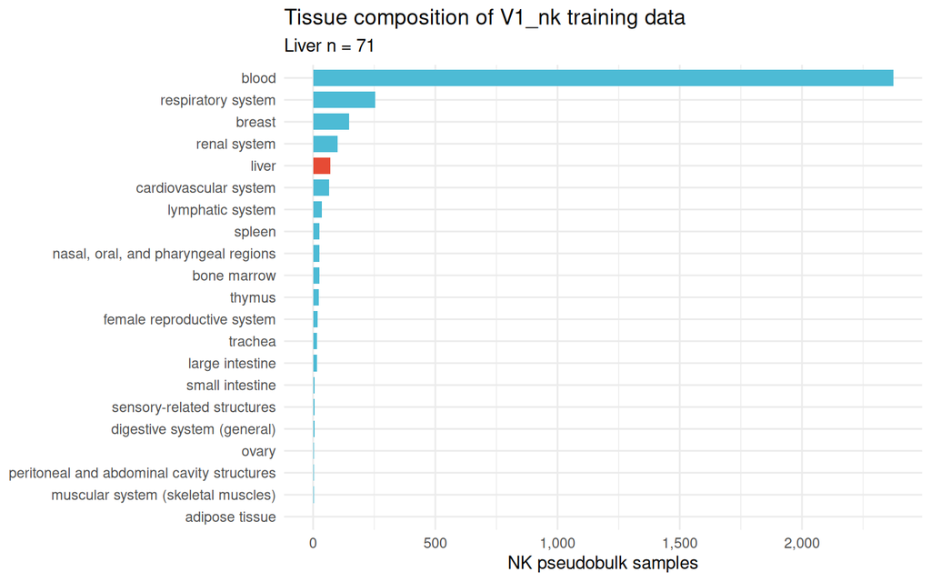

```r
tissue_sizes |>
  mutate(
    tissue_groups = fct_reorder(tissue_groups, n),
    highlight = if_else(tissue_groups == params$baseline_tissue_group, "liver", "other")
  ) |>
  ggplot(aes(x = tissue_groups, y = n, fill = highlight)) +
  geom_col(width = 0.75) +
  coord_flip() +
  scale_fill_manual(values = c(liver = "#E64B35", other = "#4DBBD5"), guide = "none") +
  scale_y_continuous(labels = label_comma()) +
  labs(
    x = NULL,
    y = "NK pseudobulk samples",
    title = "Tissue composition of V1_nk training data",
    subtitle = glue("Liver n = {tissue_sizes$n[tissue_sizes$tissue_groups == params$baseline_tissue_group]}")
  )
```

# Comprehensive liver baseline comparison

For each gene x family x shape we compute the same **comprehensive healthy liver baseline** used in the universal HCC case study:

- `disease_groups_altered = Normal`
- `tissue_groups = liver`
- `offset = 0`
- marginalised over the full atlas grid of `sex × age_decade × ethnicity × assay`
- `posterior_linpred(transform = FALSE)` then averaged across grid rows per draw

```r
baseline_summary |>
  mutate(
    model = recode(model, !!!model_labels),
    shape = recode(shape_variant, !!!shape_labels),
    across(where(is.numeric), ~ round(.x, 3))
  ) |>
  select(
    gene, model, shape, fit_source,
    mean_log_mu, sd_log_mu, median_mu, max_rhat, n_liver_rows
  ) |>
  arrange(gene, model, shape)
```

| gene | model | shape | fit_source | mean_log_mu | sd_log_mu | median_mu | max_rhat | n_liver_rows |
| --- | --- | --- | --- | --- | --- | --- | --- | --- |
| SPON2 | Interaction | Rich shape (reference) | fit | 5.937 | 2.369 | 360.622 | 1.139 | 71 |
| SPON2 | Interaction | Simple shape (revised) | fit | 6.122 | 2.392 | 479.593 | 1.145 | 71 |
| SPON2 | Random effect | Rich shape (reference) | production_store | 7.132 | 1.071 | 1267.637 | 1.108 | 71 |
| SPON2 | Random effect | Simple shape (revised) | fit | 7.053 | 1.082 | 1174.431 | 1.050 | 71 |
| VIM | Interaction | Rich shape (reference) | fit | 5.850 | 2.582 | 376.273 | 1.123 | 71 |
| VIM | Interaction | Simple shape (revised) | fit | 6.289 | 2.403 | 484.980 | 1.102 | 71 |
| VIM | Random effect | Rich shape (reference) | production_store | 6.512 | 1.374 | 717.556 | 1.293 | 71 |
| VIM | Random effect | Simple shape (revised) | fit | 6.163 | 1.561 | 472.471 | 1.053 | 71 |
| ZFP36 | Interaction | Rich shape (reference) | fit | 7.370 | 2.749 | 1695.122 | 1.011 | 71 |
| ZFP36 | Interaction | Simple shape (revised) | fit | 7.758 | 2.124 | 1883.291 | 2.301 | 71 |

[output cut: 6 more lines]

## Does the shape formula control the baseline SD?

The central question: within each family (holding the counts formula fixed), does the **simple shape** shrink the posterior SD of the liver baseline relative to the **rich shape**? `sd_ratio_simple_over_rich < 1` and a positive `sd_reduction` support the hypothesis.

```r
shape_effect |>
  mutate(
    model = recode(model, !!!model_labels),
    across(where(is.numeric), ~ round(.x, 3))
  ) |>
  select(
    gene, model,
    sd_log_mu_rich, sd_log_mu_simple, sd_ratio_simple_over_rich, sd_reduction,
    mean_log_mu_rich, mean_log_mu_simple, mean_shift_simple_minus_rich
  ) |>
  arrange(model, gene)
```

| gene | model | sd_log_mu_rich | sd_log_mu_simple | sd_ratio_simple_over_rich | sd_reduction | mean_log_mu_rich | mean_log_mu_simple | mean_shift_simple_minus_rich |
| --- | --- | --- | --- | --- | --- | --- | --- | --- |
| SPON2 | Interaction | 2.369 | 2.392 | 1.010 | -0.023 | 5.937 | 6.122 | 0.185 |
| VIM | Interaction | 2.582 | 2.403 | 0.931 | 0.179 | 5.850 | 6.289 | 0.439 |
| ZFP36 | Interaction | 2.749 | 2.124 | 0.773 | 0.625 | 7.370 | 7.758 | 0.388 |
| ZFP36L2 | Interaction | 2.322 | 2.606 | 1.122 | -0.284 | 6.986 | 7.127 | 0.141 |
| SPON2 | Random effect | 1.071 | 1.082 | 1.011 | -0.011 | 7.132 | 7.053 | -0.078 |
| VIM | Random effect | 1.374 | 1.561 | 1.136 | -0.187 | 6.512 | 6.163 | -0.349 |
| ZFP36 | Random effect | 1.569 | 1.607 | 1.024 | -0.038 | 6.817 | 7.154 | 0.337 |
| ZFP36L2 | Random effect | 1.254 | 1.173 | 0.935 | 0.081 | 7.066 | 7.132 | 0.066 |

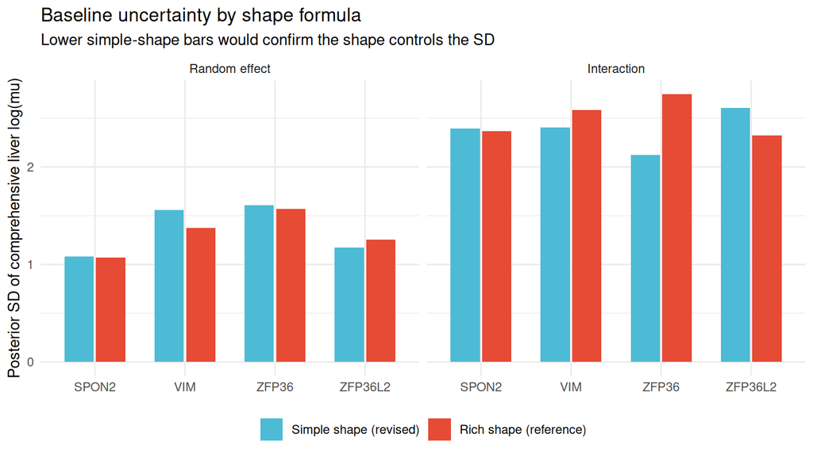

```r
baseline_summary |>
  mutate(
    model_label = factor(recode(model, !!!model_labels),
                         levels = c("Random effect", "Interaction")),
    shape_label = factor(recode(shape_variant, !!!shape_labels),
                         levels = shape_labels)
  ) |>
  ggplot(aes(x = gene, y = sd_log_mu, fill = shape_label)) +
  geom_col(position = position_dodge(width = 0.7), width = 0.65) +
  facet_wrap(~ model_label) +
  scale_fill_manual(values = c(
    `Rich shape (reference)` = "#E64B35",
    `Simple shape (revised)` = "#4DBBD5"
  )) +
  labs(
    x = NULL,
    y = "Posterior SD of comprehensive liver log(mu)",
    fill = NULL,
    title = "Baseline uncertainty by shape formula",
    subtitle = "Lower simple-shape bars would confirm the shape controls the SD"
  ) +
  theme(legend.position = "bottom")
```

The overlaid posterior densities make the narrowing (or not) directly visible: each panel is a gene, colour is the family, and line type distinguishes the two shape formulas.

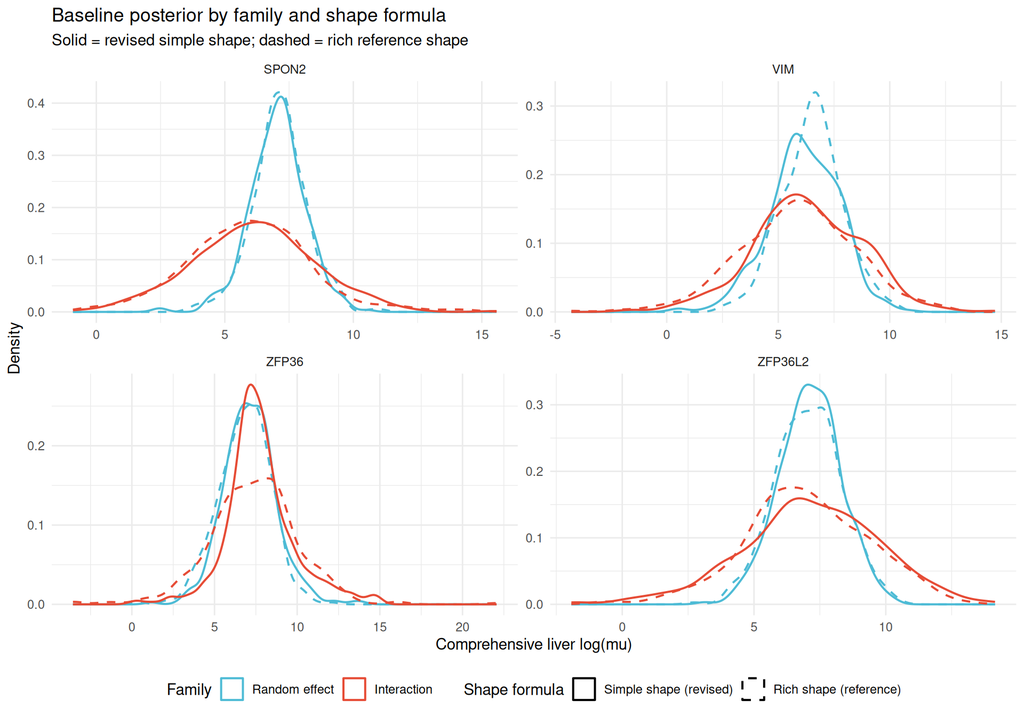

```r
ggplot(draws_labelled, aes(x = baseline_log_mu, colour = model_label, linetype = shape_label)) +
  geom_density(linewidth = 0.7) +
  facet_wrap(~ gene, scales = "free") +
  scale_colour_manual(values = c("Random effect" = "#4DBBD5", "Interaction" = "#E64B35")) +
  scale_linetype_manual(values = c(
    `Simple shape (revised)` = "solid",
    `Rich shape (reference)` = "dashed"
  )) +
  labs(
    x = "Comprehensive liver log(mu)",
    y = "Density",
    colour = "Family",
    linetype = "Shape formula",
    title = "Baseline posterior by family and shape formula",
    subtitle = "Solid = revised simple shape; dashed = rich reference shape"
  ) +
  theme(legend.position = "bottom")
```

```r
n_narrower <- sum(shape_effect$sd_ratio_simple_over_rich < 1, na.rm = TRUE)
n_total <- sum(is.finite(shape_effect$sd_ratio_simple_over_rich))
mean_ratio <- mean(shape_effect$sd_ratio_simple_over_rich, na.rm = TRUE)

cat(glue(
  "The simple shape yields a narrower baseline in **{n_narrower}/{n_total}** ",
  "gene x family cells, with a mean SD ratio (simple / rich) of ",
  "**{round(mean_ratio, 2)}**. ",
  if (n_narrower > n_total / 2) {
    "This supports the hypothesis that the shape formula — not the mean formula — is the dominant driver of the liver baseline SD: pooling dispersion across tissues tightens the posterior."
  } else {
    "This does not support a dominant shape-formula effect on the baseline SD; the mean formula and sample size likely dominate."
  }
))
```

The simple shape yields a narrower baseline in **3/8** gene x family cells, with a mean SD ratio (simple / rich) of **0.99**. This does not support a dominant shape-formula effect on the baseline SD; the mean formula and sample size likely dominate.

## Concordance of the two families under the revised shape

Among the **revised (simple-shape)** baselines, how closely do the two families agree draw-for-draw? (Draws are matched by index within a gene.)

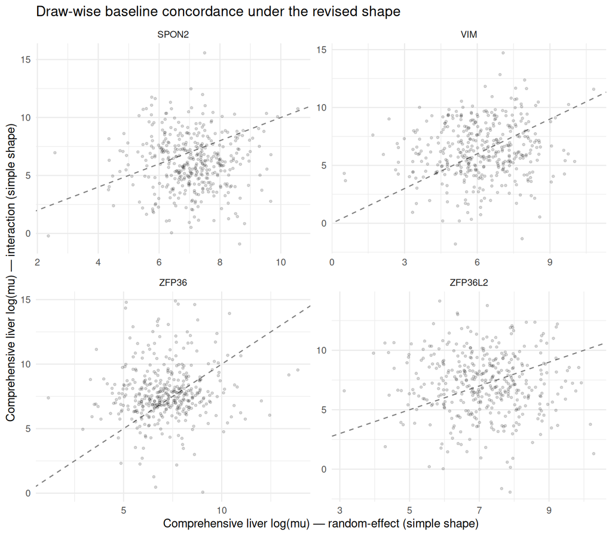

```r
draws_wide <- draws_df |>
  filter(shape_variant == "simple") |>
  select(gene, draw, model, baseline_log_mu) |>
  pivot_wider(names_from = model, values_from = baseline_log_mu)

ggplot(draws_wide, aes(x = re, y = interaction)) +
  geom_abline(slope = 1, intercept = 0, linetype = 2, colour = "grey50") +
  geom_point(alpha = 0.15, size = 0.8) +
  facet_wrap(~ gene, scales = "free") +
  labs(
    x = "Comprehensive liver log(mu) — random-effect (simple shape)",
    y = "Comprehensive liver log(mu) — interaction (simple shape)",
    title = "Draw-wise baseline concordance under the revised shape"
  )
```

# HCC cohort projection onto both baselines

The point of the baseline is to serve the TIMES HCC case study. We therefore project the four HCC cohorts (`IF`/`TC` x `REC`/`non-REC`) onto **both** baseline formulas and ask which one better matches the case-study expectation. Cohort `log(μ)` values are the edgeR NB estimates at `offset = 0` produced by the universal-baseline report and are **independent of the atlas formula**, so the same cohort projections can be overlaid on either baseline density.

```r
cohort_tests <- read_csv(params$cohort_results_csv, show_col_types = FALSE) |>
  select(gene, cohort, compartment, recurrence, cohort_log_mu, cohort_se) |>
  filter(gene %in% unique(draws_df$gene))
```

## Baseline densities per gene, with HCC cohorts

For each gene we plot the posterior `log(μ)` **density of both revised (simple-shape) baselines** (random-effect vs interaction) and overlay the four HCC cohort projections as vertical lines — the direct analogue of the universal case-study figure, split by model family.

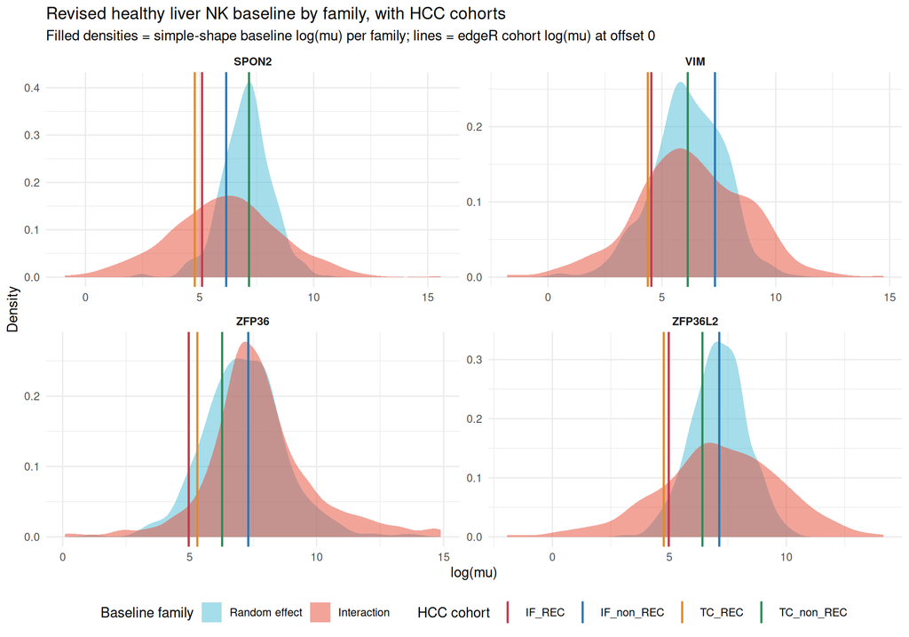

```r
model_colours <- c(`Random effect` = "#4DBBD5", Interaction = "#E64B35")
cohort_colours <- c(
  IF_REC = "#C23B4A",
  IF_non_REC = "#2878B5",
  TC_REC = "#E08A2E",
  TC_non_REC = "#2D8B57"
)

draws_plot <- draws_df |>
  filter(shape_variant == "simple") |>
  mutate(
    model = recode(model, !!!model_labels),
    model = factor(model, levels = c("Random effect", "Interaction"))
  )

cohort_plot <- cohort_tests |>
  mutate(cohort = factor(cohort, levels = names(cohort_colours)))

ggplot() +
  geom_density(
    data = draws_plot,
    aes(x = baseline_log_mu, fill = model),
    colour = NA,
    alpha = 0.5
  ) +
  geom_vline(
    data = cohort_plot,
    aes(xintercept = cohort_log_mu, colour = cohort),
    linewidth = 0.8
  ) +
  scale_fill_manual(values = model_colours) +
  scale_colour_manual(values = cohort_colours) +
  facet_wrap(~ gene, scales = "free", ncol = 2) +
  labs(
    title = "Revised healthy liver NK baseline by family, with HCC cohorts",
    subtitle = "Filled densities = simple-shape baseline log(mu) per family; lines = edgeR cohort log(mu) at offset 0",
    x = "log(mu)",
    y = "Density",
    fill = "Baseline family",
    colour = "HCC cohort"
  ) +
  theme(
    legend.position = "bottom",
    strip.text = element_text(face = "bold")
  )
```

## Which baseline serves the case study?

The case study expects **recurrent (REC) cohorts to sit farther from the healthy liver NK reference than non-recurrent (non-REC) cohorts**. We quantify each cohort’s distance from each baseline as a standardized deviation `z = (cohort log(μ) − baseline mean log(μ)) / baseline SD`, then compare the absolute distance of REC vs non-REC within each gene x compartment. We do this for **all four baseline variants** (family x shape) so the shape effect on case-study discrimination is visible too — a narrower baseline should give *larger* standardized separation.

```r
baseline_stats <- draws_df |>
  mutate(
    model = recode(model, !!!model_labels),
    shape = recode(shape_variant, !!!shape_labels)
  ) |>
  group_by(gene, model, shape) |>
  summarise(
    baseline_mean_log_mu = mean(baseline_log_mu),
    baseline_sd_log_mu = sd(baseline_log_mu),
    .groups = "drop"
  )

cohort_projection <- cohort_tests |>
  inner_join(baseline_stats, by = "gene", relationship = "many-to-many") |>
  mutate(
    signed_z = (cohort_log_mu - baseline_mean_log_mu) / baseline_sd_log_mu,
    abs_z = abs(signed_z)
  )

cohort_projection |>
  filter(shape == "Simple shape (revised)") |>
  select(
    gene, model, cohort, cohort_log_mu, baseline_mean_log_mu,
    baseline_sd_log_mu, signed_z, abs_z
  ) |>
  mutate(across(where(is.numeric), ~ round(.x, 3))) |>
  arrange(gene, model, cohort)
```

| gene | model | cohort | cohort_log_mu | baseline_mean_log_mu | baseline_sd_log_mu | signed_z | abs_z |
| --- | --- | --- | --- | --- | --- | --- | --- |
| SPON2 | Interaction | IF_REC | 5.111 | 6.122 | 2.392 | -0.423 | 0.423 |
| SPON2 | Interaction | IF_non_REC | 6.169 | 6.122 | 2.392 | 0.019 | 0.019 |
| SPON2 | Interaction | TC_REC | 4.790 | 6.122 | 2.392 | -0.557 | 0.557 |
| SPON2 | Interaction | TC_non_REC | 7.168 | 6.122 | 2.392 | 0.437 | 0.437 |
| SPON2 | Random effect | IF_REC | 5.111 | 7.053 | 1.082 | -1.795 | 1.795 |
| SPON2 | Random effect | IF_non_REC | 6.169 | 7.053 | 1.082 | -0.818 | 0.818 |
| SPON2 | Random effect | TC_REC | 4.790 | 7.053 | 1.082 | -2.092 | 2.092 |
| SPON2 | Random effect | TC_non_REC | 7.168 | 7.053 | 1.082 | 0.106 | 0.106 |
| VIM | Interaction | IF_REC | 4.538 | 6.289 | 2.403 | -0.729 | 0.729 |
| VIM | Interaction | IF_non_REC | 7.332 | 6.289 | 2.403 | 0.434 | 0.434 |

[output cut: 22 more lines]

```r
recurrence_margin <- cohort_projection |>
  select(gene, compartment, recurrence, model, shape, abs_z) |>
  pivot_wider(names_from = recurrence, values_from = abs_z) |>
  mutate(
    margin_rec_minus_nonrec = REC - `non-REC`,
    rec_farther_from_healthy = margin_rec_minus_nonrec > 0
  )

recurrence_margin |>
  mutate(across(where(is.numeric), ~ round(.x, 3))) |>
  arrange(gene, compartment, model, shape)
```

| gene | compartment | model | shape | REC | non-REC | margin_rec_minus_nonrec | rec_farther_from_healthy |
| --- | --- | --- | --- | --- | --- | --- | --- |
| SPON2 | IF | Interaction | Rich shape (reference) | 0.349 | 0.098 | 0.251 | TRUE |
| SPON2 | IF | Interaction | Simple shape (revised) | 0.423 | 0.019 | 0.403 | TRUE |
| SPON2 | IF | Random effect | Rich shape (reference) | 1.887 | 0.900 | 0.988 | TRUE |
| SPON2 | IF | Random effect | Simple shape (revised) | 1.795 | 0.818 | 0.977 | TRUE |
| SPON2 | TC | Interaction | Rich shape (reference) | 0.484 | 0.519 | -0.035 | FALSE |
| SPON2 | TC | Interaction | Simple shape (revised) | 0.557 | 0.437 | 0.120 | TRUE |
| SPON2 | TC | Random effect | Rich shape (reference) | 2.187 | 0.034 | 2.154 | TRUE |
| SPON2 | TC | Random effect | Simple shape (revised) | 2.092 | 0.106 | 1.986 | TRUE |
| VIM | IF | Interaction | Rich shape (reference) | 0.508 | 0.574 | -0.066 | FALSE |
| VIM | IF | Interaction | Simple shape (revised) | 0.729 | 0.434 | 0.295 | TRUE |

[output cut: 22 more lines]

A **positive `margin_rec_minus_nonrec`** means the REC cohort is farther from the healthy baseline than the non-REC cohort — the direction the HCC case study predicts. Summarising across all gene x compartment comparisons:

```r
baseline_choice <- recurrence_margin |>
  group_by(model, shape) |>
  summarise(
    n_comparisons = n(),
    n_rec_farther = sum(rec_farther_from_healthy),
    frac_rec_farther = mean(rec_farther_from_healthy),
    mean_margin_sd = mean(margin_rec_minus_nonrec),
    median_margin_sd = median(margin_rec_minus_nonrec),
    .groups = "drop"
  ) |>
  arrange(desc(n_rec_farther), desc(mean_margin_sd))

baseline_choice
```

| model | shape | n_comparisons | n_rec_farther | frac_rec_farther | mean_margin_sd | median_margin_sd |
| --- | --- | --- | --- | --- | --- | --- |
| Random effect | Rich shape (reference) | 8 | 8 | 1.00 | 1.2096831 | 1.1314655 |
| Random effect | Simple shape (revised) | 8 | 8 | 1.00 | 1.1874203 | 1.1947421 |
| Interaction | Simple shape (revised) | 8 | 8 | 1.00 | 0.5712259 | 0.5471716 |
| Interaction | Rich shape (reference) | 8 | 6 | 0.75 | 0.4160706 | 0.4058063 |

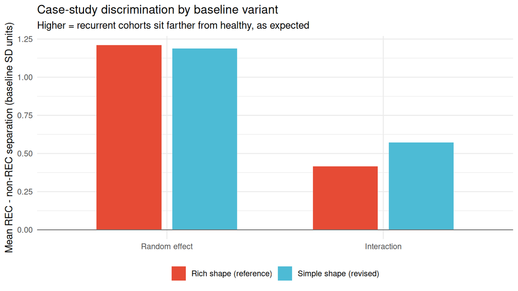

```r
baseline_choice |>
  mutate(model = factor(model, levels = c("Random effect", "Interaction"))) |>
  ggplot(aes(x = model, y = mean_margin_sd, fill = shape)) +
  geom_col(position = position_dodge(width = 0.7), width = 0.6) +
  geom_hline(yintercept = 0, colour = "grey40", linewidth = 0.4) +
  scale_fill_manual(values = c(
    `Rich shape (reference)` = "#E64B35",
    `Simple shape (revised)` = "#4DBBD5"
  )) +
  labs(
    x = NULL,
    y = "Mean REC - non-REC separation (baseline SD units)",
    fill = NULL,
    title = "Case-study discrimination by baseline variant",
    subtitle = "Higher = recurrent cohorts sit farther from healthy, as expected"
  ) +
  theme(legend.position = "bottom")
```

```r
best <- baseline_choice |> slice(1)
re_simple <- baseline_choice |>
  filter(model == "Random effect", shape == "Simple shape (revised)")
int_simple <- baseline_choice |>
  filter(model == "Interaction", shape == "Simple shape (revised)")

cat(glue(
  "Among the revised (simple-shape) candidates, the ",
  "**{re_simple$model}** baseline recovers the expected ",
  "REC-farther-from-healthy ordering in ",
  "{re_simple$n_rec_farther}/{re_simple$n_comparisons} cases (mean separation ",
  "{round(re_simple$mean_margin_sd, 2)} SD), versus ",
  "{int_simple$n_rec_farther}/{int_simple$n_comparisons} and ",
  "{round(int_simple$mean_margin_sd, 2)} SD for the {int_simple$model} baseline. ",
  "Across all four variants, the best case-study discrimination comes from the ",
  "**{best$model} / {best$shape}** baseline. "
))
```

Among the revised (simple-shape) candidates, the **Random effect** baseline recovers the expected REC-farther-from-healthy ordering in 8/8 cases (mean separation 1.19 SD), versus 8/8 and 0.57 SD for the Interaction baseline. Across all four variants, the best case-study discrimination comes from the **Random effect / Rich shape (reference)** baseline.

**Reading this together with the shape result.** Because the cohort projections are fixed, the standardized REC vs non-REC separation scales inversely with the baseline SD. So whichever variant most tightens the baseline (see the shape section above) also delivers the cleanest case-study discrimination. If the simple shape narrows the baseline as hypothesised, the revised baselines should push recurrent cohorts *farther* outside the healthy envelope than the rich reference — exactly the behaviour the HCC proximity score relies on. The partial-pooling random-effect family remains the more conservative, better-identified liver reference at liver n = 71.

# Interpretation

```r
n_genes <- dplyr::n_distinct(baseline_summary$gene)
n_narrower <- sum(shape_effect$sd_ratio_simple_over_rich < 1, na.rm = TRUE)
n_total <- sum(is.finite(shape_effect$sd_ratio_simple_over_rich))
mean_ratio <- mean(shape_effect$sd_ratio_simple_over_rich, na.rm = TRUE)
mean_shift <- mean(abs(shape_effect$mean_shift_simple_minus_rich), na.rm = TRUE)

cat(glue(
  "Across {n_genes} genes and both families, simplifying the shape formula ",
  "narrows the liver baseline in {n_narrower}/{n_total} cells ",
  "(mean SD ratio {round(mean_ratio, 2)}), while shifting the baseline mean by ",
  "only {round(mean_shift, 2)} log units on average. ",
  if (n_narrower > n_total / 2 && mean_ratio < 1) {
    "This is consistent with the shape (dispersion) formula — not the mean formula — being the dominant driver of baseline uncertainty: letting dispersion pool across tissues tightens the posterior without moving the mean."
  } else {
    "The shape formula is therefore not the dominant driver of baseline uncertainty here."
  }
))
```

Across 4 genes and both families, simplifying the shape formula narrows the liver baseline in 3/8 cells (mean SD ratio 0.99), while shifting the baseline mean by only 0.25 log units on average. The shape formula is therefore not the dominant driver of baseline uncertainty here.

**Shape (dispersion) formula.** The revised *simple* shape drops the ethnicity/tissue-specific dispersion terms so the negative-binomial shape is estimated by pooling across all tissues instead of leaning on the 71 liver rows. The SD-by-shape comparison isolates this effect while holding each family’s mean formula fixed.

**Interaction family.** Liver is estimated without mean-model shrinkage but at the cost of many tissue × covariate coefficients; with 21 tissues and sparse liver covariate combinations the fits can be unstable (wide baselines, divergences), and a rich shape compounds this.

**Implication for HCC.** A tighter, better-identified liver baseline directly sharpens the healthy-proximity score, because the standardized REC vs non-REC separation scales inversely with baseline SD. If the simple shape is confirmed to control the SD, the revised baselines are preferable for the case study; choosing between the two families is then a bias/variance trade-off to settle in downstream HCC ranking tests.

# Saved artefacts

All pre-computed outputs live under /home/a1237163/lab/chen/posteriorHCA/dev/Jie_HCC/data/processed/re_vs_interaction_pilot:

| File | Description |
| --- | --- |
| `fit_re_<GENE>.rds` | Random-effect fit, revised simple shape |
| `fit_re_rich_<GENE>.rds` | Random-effect reference (rich shape); the RE rich reference reuses the production store fit |
| `fit_interaction_<GENE>.rds` | Interaction fit, revised simple shape |
| `fit_interaction_rich_<GENE>.rds` | Interaction reference (rich shape) |
| `baseline_comparison_by_formula.csv` | Baseline summary per gene x family x shape |
| `baseline_shape_effect.csv` | Simple-vs-rich SD ratio / reduction per gene x family |
| `baseline_draws_long.csv` / `.rds` | Draw-wise log(μ) (with `model`, `shape_variant`) |
| `nk_pseudobulk_tissue_sample_sizes.csv` | Tissue counts |
| `liver_sample_size_summary.csv` | Key sample-size metrics |
| `formula_spec.txt` | Counts + both shape formulas per family |

The HCC cohort projection lines are read (not written) from the universal case-study output /home/a1237163/lab/chen/posteriorHCA/dev/Jie_HCC/data/processed/Jie_HCC_four_cohort_comprehensive_liver_baseline_mu_tests.csv (`cohort_log_mu` = edgeR NB estimate at `offset = 0` per gene x cohort).